# Finanskrisen

Udvikling, transmission og eftervirkninger

Niklas Lehmann Jensen

#### Dagens spørgsmål

- Hvordan kunne faldende huspriser i ét amerikansk lånesegment vælte banker globalt?
- Hvilken rolle spillede **gearing, securitisering og kort funding**?
- Hvordan kan markedsstress ramme investorer, selv når realkreditinstituttets funding er matchet?
- Hvad ændrede Basel-reglerne efter krisen?
- Hvad viser Silicon Valley Bank i 2023 om de samme balancemekanismer?

#### Lave renter gav brændstof til et boligboom

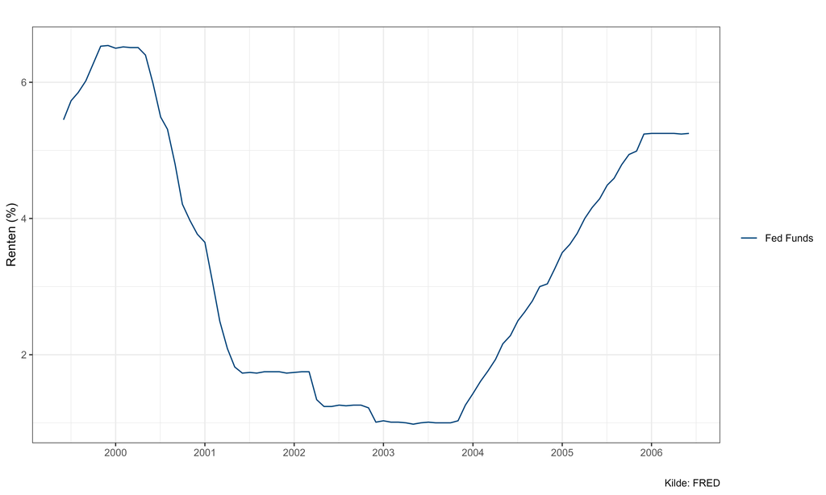

- Fed funds nåede **1 % i 2003** og blev holdt lav længe

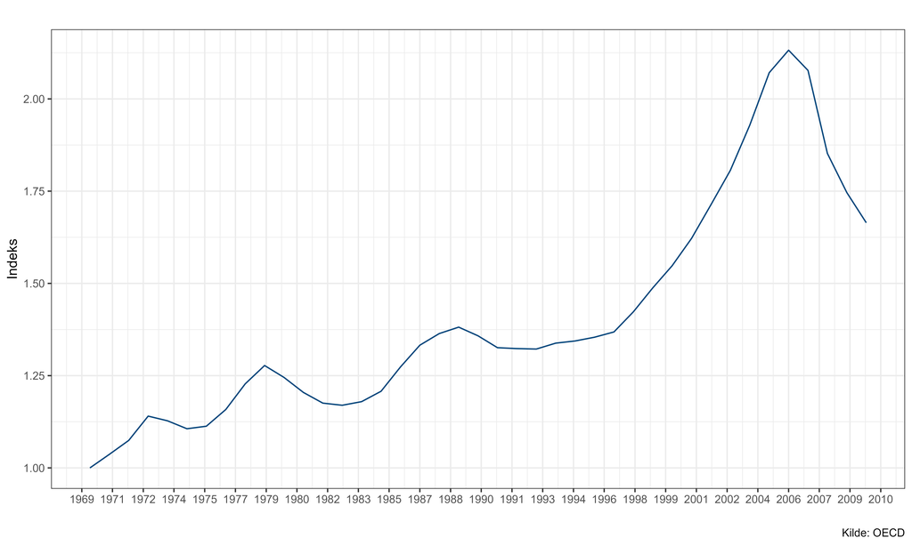

- Reale huspriser steg omkring **40 % fra 2000 til 2007**

#### Kreditkvaliteten gled ned ad risikostigen

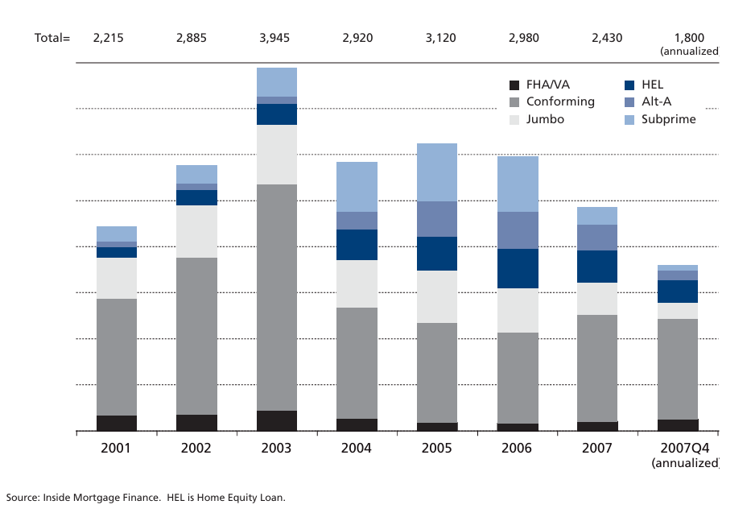

- Prime faldt fra ca. **85 % i 2001** til **52 % i 2006**
- Subprime, Alt-A og HEL steg fra ca. 15 % til næsten halvdelen
- Teaser-renter, meget høj LTV og svag dokumentation
- Modellen krævede refinansiering, før højere ydelser slog igennem

## Maskinen bag transmissionen

#### Securitisering omfordelte risikoen — den fjernede den ikke

[figure not shown]

#### USA og Danmark placerede tabene forskelligt

| Led | Amerikansk krisekæde | Dansk realkredits kerne |
| --- | --- | --- |
| Kreditbeslutning | Låneudsteder kunne sælge lån og meget af kreditrisikoen videre | Instituttet beholder kreditrisikoen og dækker tab med kapital |
| Finansiering | RMBS, nye trancher og CDO’er; dele finansieret kort via repo/ABCP | Obligationer matcher lånets centrale egenskaber via balanceprincippet |
| Investor | Tranchevandfald og flere lag gjorde risikoplaceringen uklar | Investor bærer især kurs-, rente-, konverterings- og likviditetsrisiko |
| Stress | Kredit, uigennemsigtighed og kort funding forstærkede hinanden | Kredit rammer instituttet; spænd og likviditet kan presse investor |

**Indsigt**

Forskellen er **transmissionen og tabenes placering** — ikke at Danmark var upåvirket.

#### Shadow banking gjorde lang risiko afhængig af kort funding

- Banklignende kreditformidling med et smallere sikkerhedsnet
- Lange, illikvide aktiver finansieret med **repo og ABCP**
- Kort gæld skulle løbende fornyes
- Långivere kunne undlade at rulle funding — et run uden almindelige indskud

**Advarsel**

En institution kan løbe tør for likviditet, før markedet ved, om den er solvent.

#### Gearing lader egenkapitalen bære hele prisfaldet

[figure not shown]

#### Lehmans buffer var kun 4,1 %

**Kapitalandel**

$$\frac{26{,}276}{639{,}432}=\mathbf{4{,}1\%}$$

**Gearing**

$$\frac{639{,}432}{26{,}276}\approx\mathbf{24}$$

| Lehman Q1 2008 | Mia. USD |
| --- | --- |
| Cash og andre | 61,265 |
| Værdipapirer og finansielle instrumenter | 196,997 |
| Reverse repo m.v. | 299,283 |
| Andre aktiver | 81,887 |
| **Aktiver i alt** | **639,432** |
| **Egenkapital** | **26,276** |

**Advarsel**

Et ensidigt aktivfald på omkring 4,1 % kan i en statisk illustration udhule hele egenkapitalen.

## Da tilliden forsvandt

#### Kreditproblemet blev en systemisk fundingkrise

1. Fed hævede fra 2004 → ARM-ydelser steg
2. Misligholdelser ramte strukturerede papirer
3. Ingen vidste sikkert, **hvor tabene lå**
4. Kort funding frøs → brandsalg → nye tab
5. Lehman, september 2008 → global panik

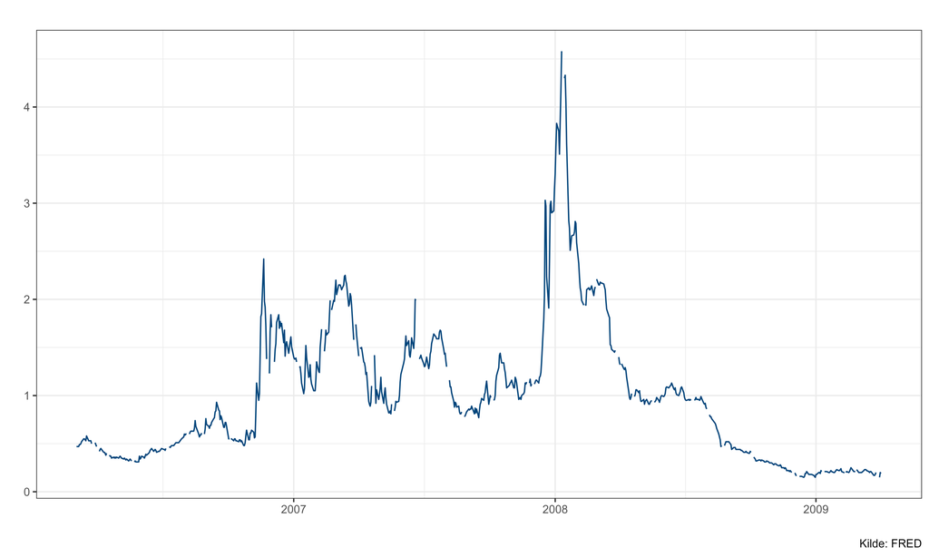

#### Robust realkreditstruktur forhindrede ikke markedsstress

[figure not shown]

#### Krisen efterlod et vedvarende lavere vækstspor

- Fed funds til **0–0,25 %** fra december 2008
- Likviditet, garantier, rekapitaliseringer og senere QE
- USA’s budgetunderskud nåede **9,9 % af BNP i 2009**
- Global aktivitet forblev under den mekanisk forlængede førkrisetrend

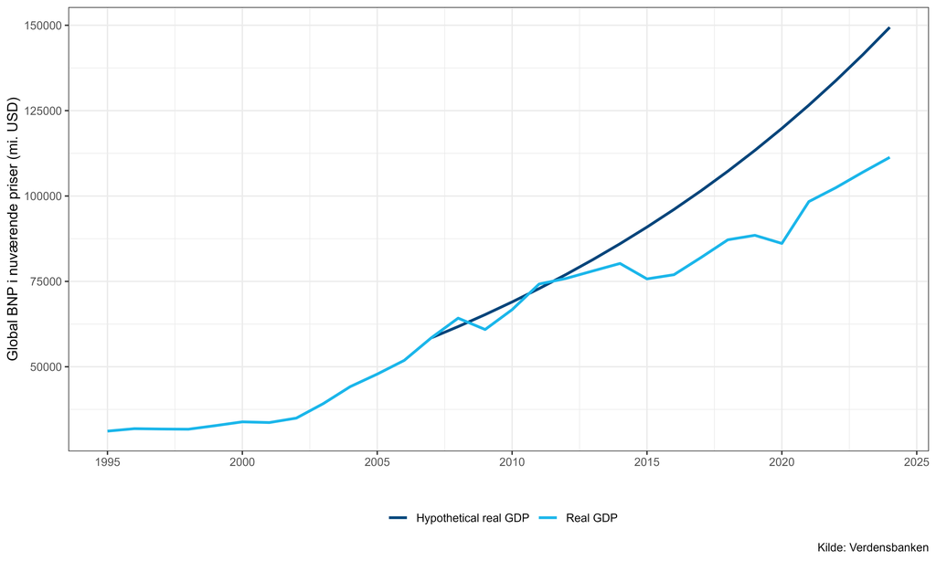

## Regulering som svar

#### Basel III svarede punkt for punkt på sårbarhederne

| Krisens svaghed | Regulatorisk svar |
| --- | --- |
| For lidt kapital af høj kvalitet | CET1-minimum **4,5 %** af RWA + kapitalbevaringsbuffer **2,5 %** |
| Meget lave modelbaserede risikovægte | Ikke-risikovægtet gearingskrav som backstop |
| Store 30-dages nettoudstrømninger | **LCR**: likvid buffer mod kort stress |
| Strukturelt kort funding | **NSFR**: mere stabil finansieringsprofil |
| Stor modelspredning | Afsluttende reformer: output floor **72,5 %** af standard-RWA |

**Indsigt**

Et bufferbrud begrænser bl.a. udlodninger; det er ikke automatisk insolvens.

#### De tre søjler fordeler ansvar for robusthed

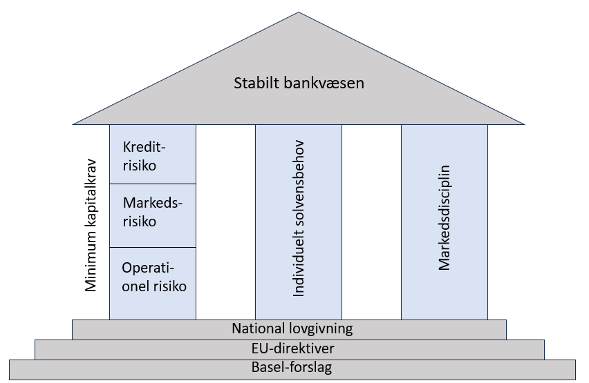

- **Søjle 1:** minimumskapital for kredit-, markeds- og operationel risiko
- **Søjle 2:** tilsyn, ICAAP og ekstra kapital for ikke-dækkede risici
- **Søjle 3:** transparens og markedsdisciplin

## Samme mekanisme i 2023

#### SVB havde lav kreditrisiko — men et stort varighedsgab

- Lange fastforrentede stats-, agency- og MBS-papirer
- Koncentrerede, store og uforsikrede indlån
- HTM udskød regnskabseffekten, men fjernede ikke økonomisk renterisiko
- Digitalt run gjorde fundingproblemet akut

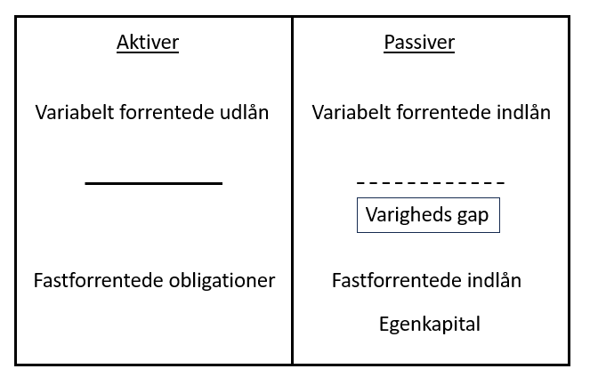

#### Balanceprofilen — ikke aktivklassen alene — skabte sårbarheden

|  | Standard bank | SVB-lignende bank |
| --- | --- | --- |
| Udlån: varighed / værdi | 2,0 / 70 | 2,0 / 20 |
| Obligationer: varighed / værdi | 3,0 / 20 | 6,0 / 70 |
| Likvider: varighed / værdi | 0,0 / 10 | 0,0 / 10 |
| **Aktivvarighed $V_A$ / aktiver** | **2,0 / 100** | **4,6 / 100** |
| Indlån: varighed / værdi | 2,0 / 90 | 0,25 / 82 |
| **Egenkapital** | **10** | **18** |
| **Passivvarighed $V_P$** | **2,0** | **0,25** |

**Indsigt**

Det stiliserede SVB-eksempel har **mere** bogført kapital end standardbanken — mismatch og kapital er forskellige risikodimensioner.

#### Gearing blæser varighedsgabet op i egenkapitalen

$$V_E=V_P+\frac{MVA}{MVE}(V_A-V_P)$$

**Standard bank**

$$V_E=2{,}0+\frac{100}{10}(2{,}0-2{,}0)=\mathbf{2{,}0}$$

**SVB-lignende bank**

$$V_E=0{,}25+\frac{100}{18}(4{,}6-0{,}25)=\mathbf{24{,}4}$$

**Advarsel**

Et rentehop på 1 procentpoint giver i første orden ca. **−2 %** mod **−24 %** på egenkapitalens markedsværdi.

#### Samme mekanisme, ny forklædning

| Dimension | 2008 | SVB 2023 |
| --- | --- | --- |
| Aktivproblem | Kredit, spænd og komplekse boligprodukter | Renterisiko på lange papirer med lav kreditrisiko |
| Funding | Repo, ABCP og anden kort wholesale-funding | Koncentrerede, uforsikrede indlån |
| Hastighed | Markedspanik og institutionelle runs | Digital adgang og tætte netværk accelererede run’et |
| Fælles kerne | Aktivtab rammer en gearet balance; kort funding kan forsvinde hurtigt | Aktivtab rammer en gearet balance; kort funding kan forsvinde hurtigt |

**Indsigt**

Kapital, varighedsgab og likviditetsberedskab er forskellige risikodimensioner — og skal styres hver for sig.

#### The Takeaways

1. Lave renter, search for yield og svag kreditgivning gjorde boligmarkedet sårbart.
2. Securitisering flyttede risiko rundt; korrelation og uigennemsigtighed gjorde tab systemiske.
3. Høj gearing betyder, at små aktivfald kan udslette egenkapitalen.
4. Balanceprincippet begrænser instituttets markedsrisiko, men fjerner ikke investorernes markeds- og likviditetsrisiko.
5. Basel svarede med kapital, gearingsbackstop, LCR, NSFR og et output floor.
6. SVB viste, at renterisiko, koncentreret funding og et hurtigt run kan vælte en bank uden klassiske kredittab.

## Øvelser

#### Øvelser: følg tabet gennem systemet

1. **Boligejerens balance:** Beregn egenkapital og LTV ved 80 % og 100 % startbelåning samt prisfald på 10, 20 og 30 %.
2. **Gearing:** En bank har aktiver 500 mia. kr. og EK 15 mia. kr. Beregn kapitalandel, gearing og et statisk insolvenspunkt.
3. **Tranchevandfald:** Fordel tab på 5, 15 og 35 mio. kr. i en pulje med senior 70, mezzanine 20 og equity 10.
4. **DK 2008:** Forklar med pensionsfiguren forskellen mellem værdiændring og nettosalg — og hvad figuren ikke kan bevise.

#### Øvelser: regulering og den nye forklædning

5. **Rentemarginal:** Indlån 0,25 % og 10-årige obligationer 1,75 %. Hvilken risiko finansierer merafkastet ved et rentehop på 2 procentpoint?
6. **Egenkapitalens varighed:** $V_A=5$, $V_P=0{,}5$, gearing 8. Beregn $V_E$ og førsteordenseffekten af +2 procentpoint.
7. **2008 vs. 2023:** Sammenlign risikotype, fundingstruktur og hastighed. Hvad er fælles?
8. **Basel:** Kobl tynd kapital, lave risikovægte, 30-dages udstrømning og strukturelt kort funding til de relevante krav.